# 7-DBSCAN

# dbscan Example

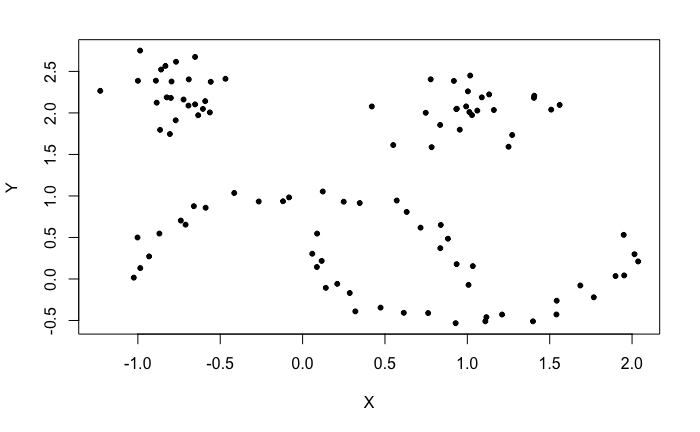

```r
# install.packages("dbscan") # install if necessary
library("dbscan")
#install.packages("fpc")
library("fpc")
library('factoextra')
#moons dataset Contains 100 2-D points, half of which are contained in two # moons or “blobs” (25 points each blob), and the other half in asymmetric # facing crescent shapes.
data("moons")
plot(moons, pch=20) # plot original data points
```

The data shows both nonlinearity and different densities.

Let us apply dbscan to this example

```r
db <- dbscan::dbscan(moons, eps = 0.5, minPts = 5) #perform clustering
print(db) #print cluster details
```

```
DBSCAN clustering for 100 objects.
Parameters: eps = 0.5, minPts = 5
The clustering contains 3 cluster(s) and 0 noise points.

 1  2  3
50 25 25

Available fields: cluster, eps, minPts
```

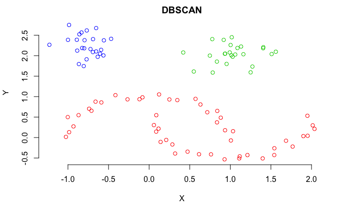

```r
plot(db, moons, main = "DBSCAN", frame = FALSE) #plot cluster details
```

# fpc Package

Let us now apply the fpc package to an example

```r
# install_packages("fpc")
library('factoextra')
library('fpc')
df <- multishapes[, 1:2]
set.seed(123)
db <- fpc::dbscan(df, eps = 0.15, MinPts = 5) # DBSCAN using fpc package
print(db) # show clusters' details
```

```
dbscan Pts=1100 MinPts=5 eps=0.15
        0   1   2   3  4  5
border 31  24   1   5  7  1
seed    0 386 404  99 92 50
total  31 410 405 104 99 51
```

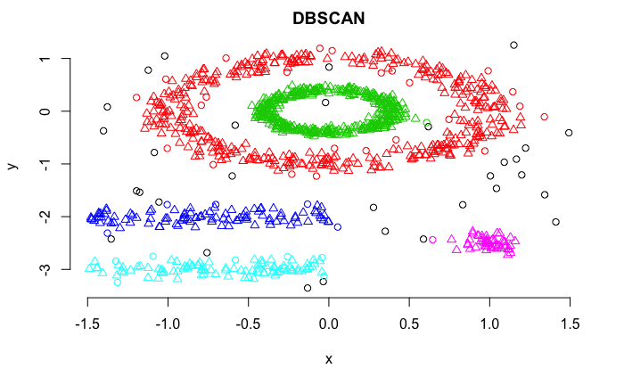

```r
# Plot DBSCAN results
plot(db, df, main = "DBSCAN", frame = FALSE)
```

The colored triangles indicate core points, while the colored circles border points. The black circles indicates noise (outliers).

Here is an alternative way to depict the same plot

```
argument frame is deprecated; please use ellipse instead.
```

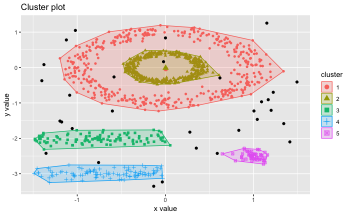

```r
fviz_cluster(db, df,   stand = FALSE, frame = FALSE, geom = "point") # Alternative way to depict plot
```

## Optimal eps value

dbscan is sensitive to changes in eps values, as the below example illustrates.

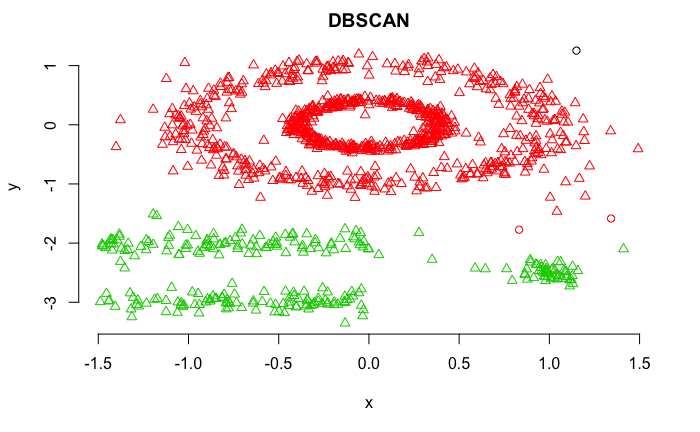

```r
db <- fpc::dbscan(df, eps = 0.5, MinPts = 5)
plot(db, df, main = "DBSCAN", frame = FALSE)
```

As you can clearly see, changing the neighborhood changes the categorization of the points. Many of the noise points now belong to a cluster, and there are fewer border points.

To determine the optimal eps, we compute the the k-nearest neighbor distances in a matrix of points.The idea is to calculate, the average of the distances of every point to its k nearest neighbors. The value of k will be specified by the user and corresponds to MinPts. Next, these k-distances are plotted in an ascending order. The aim is to determine the “knee”, which corresponds to the optimal eps parameter.

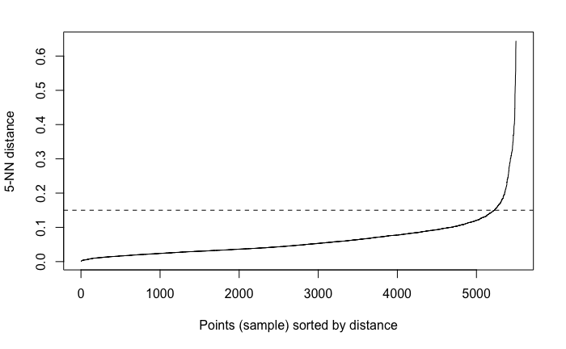

```r
dbscan::kNNdistplot(df, k =  5)
abline(h = 0.15, lty = 2)
```

Based on the “knee” plot above, the optimal eps = 0.15.